# Case Study: Cyclistic Bike Share

Aaron Tae

5/29/2022

## Introduction

This is the capstone project for the Google Data Analytics Certificate.

Cyclistic is a fictional bike-share company in Chicago that features more than 5,800 bicycles and 600 docking stations.

There are three types of passes customers can purchase for Cyclistic’s services: single-day passes, full-day passes annual memberships.

Also, Cyclisitic’s customers can be divided into two main groups:

1. Casual Riders - customers who purchase single-day passes and full-day passes
2. Cyclistic members - customers who purchase annual memberships

Cyclistic’s finance analysts concluded that annual members are much more profitable than casual riders. Therefore, Cyclistic’s director of marketing, Lily Moreno, believes that the key to the company’s success depends on maximizing the number of annual members.

For more information on this project, [click here](https://www.coursera.org/professional-certificates/google-data-analytics).

## Phase 1 - Ask

#### Goal

Design market strategies to convert casual riders into annual members.

#### Guiding Questions

How do annual members and casual riders use Cyclistic bikes differently?

#### Business Task

Identify and analyze the differences between casual riders and annual members of Cyclistic customers in order to increase the conversion rate of casual riders into annual members.

#### Key Stakeholders

- Cyclistic executive team
- Lily Moreno - Director of Marketing and my manager

## Phase 2 - Prepare

#### Source of Data

The data used is public data that is provided by Motivate International Inc.  
The data is made available under [this license](https://ride.divvybikes.com/data-license-agreement).

#### Data Organization

The data used is original, and is collected from the last 12 months (May 2021 ~ April 2022), with a CSV files for each month.

Each CSV file has 13 variables (columns). I removed 3 variables of which I deemed unnecessary (end station name & start/end station id).

The resulting data sets have 10 variables each:

- ride_id
- rideable_type - type of bike rented
- start_station_name
- started_at
- ended_at
- start_lat - start latitude
- end_lat
- start_lng - start longitude
- end_lng
- member_casual - member status

## Phase 3 - Process

#### Data Cleaning

```r
# drop unnecessary columns and also drop NA values
drops <- c("end_station_name", "start_station_id", "end_station_id")
may_2021 <- drop_na(may_2021[, (!names(may_2021) %in% drops)]) %>% unique()
jun_2021 <- drop_na(jun_2021[, (!names(jun_2021) %in% drops)]) %>% unique()
jul_2021 <- drop_na(jul_2021[, (!names(jul_2021) %in% drops)]) %>% unique()
aug_2021 <- drop_na(aug_2021[, (!names(aug_2021) %in% drops)]) %>% unique()
sep_2021 <- drop_na(sep_2021[, (!names(sep_2021) %in% drops)]) %>% unique()
oct_2021 <- drop_na(oct_2021[, (!names(oct_2021) %in% drops)]) %>% unique()
nov_2021 <- drop_na(nov_2021[, (!names(nov_2021) %in% drops)]) %>% unique()
dec_2021 <- drop_na(dec_2021[, (!names(dec_2021) %in% drops)]) %>% unique()
jan_2022 <- drop_na(jan_2022[, (!names(jan_2022) %in% drops)]) %>% unique()
feb_2022 <- drop_na(feb_2022[, (!names(feb_2022) %in% drops)]) %>% unique()
mar_2022 <- drop_na(mar_2022[, (!names(mar_2022) %in% drops)]) %>% unique()
apr_2022 <- drop_na(apr_2022[, (!names(apr_2022) %in% drops)]) %>% unique()
```

```r
data <- rbind(may_2021,jun_2021,jul_2021,aug_2021,sep_2021,oct_2021,nov_2021,dec_2021,jan_2022,feb_2022,mar_2022,apr_2022)

## remove all other data frames to save memory
rm(may_2021, jun_2021, jul_2021, aug_2021, sep_2021, oct_2021, nov_2021, dec_2021, jan_2022, feb_2022, mar_2022, apr_2022)
```

I then converted the ‘started_at’ and ‘ended_at’ variables to R date type variables.

```r
data$started_at <- as.POSIXct(data$started_at, format = "%Y-%m-%d %I:%M:%S %p", tz = Sys.timezone())
data$ended_at <- as.POSIXct(data$ended_at, format = "%Y-%m-%d %I:%M:%S %p", tz = Sys.timezone())
```

I then created two new variables: 1) ride_length - the length of each ride 2) day_of_week - the day of the week the ride started

```r
data$ride_length <- difftime(data$ended_at, data$started_at, units='mins')
data$day_of_week <- format(data$started_at, "%A")
```

I then removed the rows with a negative or zero value for the ride_length variable.

```r
data <- data[data$ride_length > 0, ]
```

I also created a ordered factor column that tells what day of the week the ride took place.

```r
data$day_of_week <- ordered(format(data$started_at, "%A"), levels=c("Sunday", "Monday", "Tuesday", "Wednesday", "Thursday", "Friday", "Saturday"))
```

## Phase 4 - Analysis

#### Decriptive Analysis

Descriptive statistics on ride_length variable:

```r
mean(data$ride_length)
```

```
## Time difference of 20.8008 mins
```

```r
median(data$ride_length)
```

```
## Time difference of 11.73333 mins
```

```r
max(data$ride_length)
```

```
## Time difference of 55944.15 mins
```

```r
min(data$ride_length)
```

```
## Time difference of 0.01666667 mins
```

I compared the same statistics between members vs casual riders.

```r
aggregate(data$ride_length~data$member_casual, FUN = mean)
```

```
##   data$member_casual data$ride_length
## 1             casual    30.72623 mins
## 2             member    12.97296 mins
```

```r
aggregate(data$ride_length~data$member_casual, FUN = median)
```

```
##   data$member_casual data$ride_length
## 1             casual   16.066667 mins
## 2             member    9.333333 mins
```

```r
aggregate(data$ride_length~data$member_casual, FUN = max)
```

```
##   data$member_casual data$ride_length
## 1             casual   55944.150 mins
## 2             member    1499.933 mins
```

```r
aggregate(data$ride_length~data$member_casual, FUN = min)
```

```
##   data$member_casual data$ride_length
## 1             casual  0.01666667 mins
## 2             member  0.01666667 mins
```

I then looked at the top five start stations that had the most number of rides by rider type.

```r
temp_df <- data %>%
  group_by(start_station_name) %>%
  summarize(number_of_rides=n(), casual_riders=sum(member_casual == "casual"), members = sum(member_casual == "member")) %>%
  arrange(-number_of_rides) %>%
  head(5)

write.csv(temp_df, file="~/Desktop/google_data_course/tableaedata.csv") # export file to create Tableau visualization
```

Then, I looked at the number of riders for each type of bike.

```r
temp_df2 <- data %>%
  group_by(rideable_type) %>%
  summarize(number_of_rides=n(), casual_riders=sum(member_casual == "casual"), members = sum(member_casual == "member")) %>%
  arrange(-number_of_rides) %>%
  head(5)

write.csv(temp_df2, file="~/Desktop/google_data_course/tableaudata2.csv")
```

I then analyzed the data by ride type and the day of the week.

```r
data %>%
  mutate(weekday = wday(started_at, label=TRUE)) %>%
  group_by(member_casual, weekday) %>%
  summarize(number_of_rides = n(), average_duration=mean(ride_length)) %>%
  arrange(member_casual, weekday)
```

```
## # A tibble: 14 × 4
## # Groups:   member_casual [2]
##    member_casual weekday number_of_rides average_duration
##    <chr>         <ord>             <int> <drtn>
##  1 casual        Sun              421392 35.94719 mins
##  2 casual        Mon              246664 30.58387 mins
##  3 casual        Tue              227380 26.15126 mins
##  4 casual        Wed              240697 26.75803 mins
##  5 casual        Thu              252394 27.26467 mins
##  6 casual        Fri              305776 28.79354 mins
##  7 casual        Sat              493539 33.35031 mins
##  8 member        Sun              332928 14.84954 mins
##  9 member        Mon              384397 12.53732 mins
## 10 member        Tue              431571 12.09013 mins
## 11 member        Wed              439595 12.31967 mins
## 12 member        Thu              418566 12.27109 mins
## 13 member        Fri              387040 12.68103 mins
## 14 member        Sat              380010 14.59827 mins
```

I then created a visualization for this analysis.

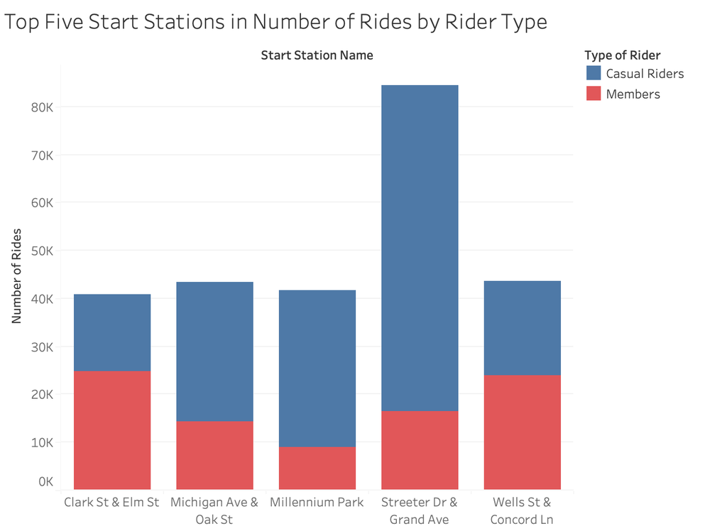

```r
# graphic produced in Tableau
knitr::include_graphics("top5graph.png")
```

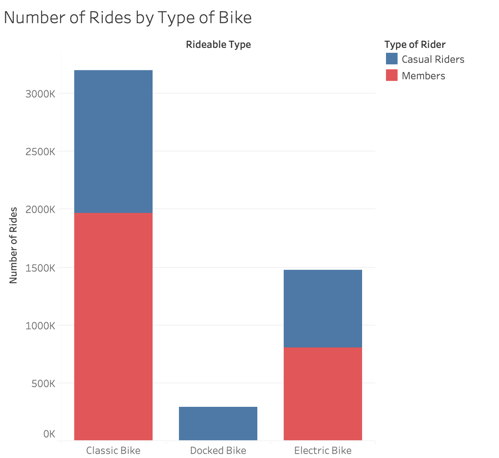

[figure not shown]

```r
# graphic produced in Tableau
knitr::include_graphics("biketype.png")
```

## Phase 5 - Share

#### Graph 1 - Top Five Start Stations by Rider Type

We can observe from the first graph that although there are more members than casual riders than Clark St. & Elm St. and Wells St. & Concord Ln., there are more casual riders than members for the other three top start stations, especially Streeter Dr. & Grand Avenue. A quick search reveals that these three start stations are located in areas that would be expected to be tourist attractions or local “hangout” areas. For example, Millenium Park is a famous tourist attraction in Chicago, and Streeter Dr. & Grand Avenue is located by the Navy Pier, which is another famous attraction. This tells us that areas that have more attractions are more likely to have a higher proportion of casual riders, while regular, busy streets are more likely to have a higher proportion of Cyclisitic members.

#### Graph 2 - Number of Rides by Type of Bike

We can instantly observe from the second graph that the Docked Bikes attract only casual members; no members ride the Docked Bikes at all. We can also notice that the most popular type of bike is the Classic Bike, which also has a greater proportion of members compared to Electric Bikes. Another point worth mentioning is that the rider type distribution is about even for Electric Bikes.

#### Graph 3 - Total Number of Rides for each Rider Type by Day of Week

A trend we can recognize is how while the number of rides increases for casual riders increase during the weekends, the number of rides actually increases during the middle of the week for members. We can observe that there are significant increases in numbers during Saturday and Sunday compared to weekdays. On the other hand, the numbers stay relatively consistent for members, with slight increases during the midweek. We can attribute this trend to the underlying reasons why a casual rider or a member might rent out a bike. Firstly, a casual rider will most likely rent out bikes when partaking in outdoor activities with family and/or friends over the weekends when people are off work. However, members are more likely to use bikes as a method of transportation to get to work, which explains why someone would become a Cyclistic member to begin with.

## Phase 6 - Act

#### Recommendations

With the analysis and visualizations that I have produced, I came up with three recommendations for Cyclistic that can be given to stakeholders:

1. Cyclistic’s marketing campaign should not target stations with high casual rider proportions. Such areas are most likely tourist attractions, which makes it improbable that riders in these areas will convert into members. Instead, Cyclistic should focus on areas with already high proportions of Cyclistic members, to convince non-members to consider becoming a member to use Cyclistic bikes as a consistent method of transportation.
2. Cyclistic should concentrate the disturbution of bike types into Classic and Electric Bikes. Since no Cyclistic members rent Docked Bikes, we know that members make the active choice of not opting for these bikes. Thus, it would be much more cost efficient to instead distribute other bikes, especially Classic bikes, which has the highest number of users.
3. A new membership model can be developed to take into account the significant rise in number of rides by casual riders during weekends. A new member subscription model that is based on weekend usage will be much more appealing to casual riders.